# Risk Factor Analysis

## Outcome Variable

**Outcome Variable:** pers_wast

## Predictor Variables

**Intervention Variable:** meducyrs

**Adjustment Set:**

- arm
- W_mage
- feducyrs
- W_mhtcm
- W_mwtkg
- W_mbmi
- W_gagebrth
- W_birthwt
- W_birthlen
- single
- delta_W_mage
- delta_feducyrs
- delta_W_mhtcm
- delta_W_mwtkg
- delta_W_mbmi
- delta_W_gagebrth
- delta_W_birthwt
- delta_W_birthlen
- delta_single

## Stratifying Variables

The analysis was stratified on these variable(s):

- agecat
- studyid
- country

## Data Summary

| agecat | studyid | country | meducyrs | pers_wast | n_cell | n |
| --- | --- | --- | --- | --- | --- | --- |
| 0-24 months | ki0047075b-MAL-ED | BANGLADESH | High | 0 | 71 | 202 |
| 0-24 months | ki0047075b-MAL-ED | BANGLADESH | High | 1 | 4 | 202 |
| 0-24 months | ki0047075b-MAL-ED | BANGLADESH | Low | 0 | 62 | 202 |
| 0-24 months | ki0047075b-MAL-ED | BANGLADESH | Low | 1 | 4 | 202 |
| 0-24 months | ki0047075b-MAL-ED | BANGLADESH | Medium | 0 | 59 | 202 |
| 0-24 months | ki0047075b-MAL-ED | BANGLADESH | Medium | 1 | 2 | 202 |
| 0-24 months | ki0047075b-MAL-ED | BRAZIL | High | 0 | 74 | 216 |
| 0-24 months | ki0047075b-MAL-ED | BRAZIL | High | 1 | 0 | 216 |
| 0-24 months | ki0047075b-MAL-ED | BRAZIL | Low | 0 | 59 | 216 |
| 0-24 months | ki0047075b-MAL-ED | BRAZIL | Low | 1 | 1 | 216 |
| 0-24 months | ki0047075b-MAL-ED | BRAZIL | Medium | 0 | 81 | 216 |
| 0-24 months | ki0047075b-MAL-ED | BRAZIL | Medium | 1 | 1 | 216 |
| 0-24 months | ki0047075b-MAL-ED | INDIA | High | 0 | 56 | 210 |
| 0-24 months | ki0047075b-MAL-ED | INDIA | High | 1 | 4 | 210 |
| 0-24 months | ki0047075b-MAL-ED | INDIA | Low | 0 | 63 | 210 |
| 0-24 months | ki0047075b-MAL-ED | INDIA | Low | 1 | 10 | 210 |
| 0-24 months | ki0047075b-MAL-ED | INDIA | Medium | 0 | 72 | 210 |
| 0-24 months | ki0047075b-MAL-ED | INDIA | Medium | 1 | 5 | 210 |
| 0-24 months | ki0047075b-MAL-ED | NEPAL | High | 0 | 53 | 223 |
| 0-24 months | ki0047075b-MAL-ED | NEPAL | High | 1 | 0 | 223 |
| 0-24 months | ki0047075b-MAL-ED | NEPAL | Low | 0 | 93 | 223 |
| 0-24 months | ki0047075b-MAL-ED | NEPAL | Low | 1 | 1 | 223 |
| 0-24 months | ki0047075b-MAL-ED | NEPAL | Medium | 0 | 74 | 223 |
| 0-24 months | ki0047075b-MAL-ED | NEPAL | Medium | 1 | 2 | 223 |
| 0-24 months | ki0047075b-MAL-ED | PERU | High | 0 | 85 | 283 |
| 0-24 months | ki0047075b-MAL-ED | PERU | High | 1 | 0 | 283 |
| 0-24 months | ki0047075b-MAL-ED | PERU | Low | 0 | 98 | 283 |
| 0-24 months | ki0047075b-MAL-ED | PERU | Low | 1 | 0 | 283 |
| 0-24 months | ki0047075b-MAL-ED | PERU | Medium | 0 | 99 | 283 |
| 0-24 months | ki0047075b-MAL-ED | PERU | Medium | 1 | 1 | 283 |

[output cut: 396 more lines]

The following strata were considered:

- agecat: 0-24 months, studyid: ki0047075b-MAL-ED, country: BANGLADESH
- agecat: 0-24 months, studyid: ki0047075b-MAL-ED, country: BRAZIL
- agecat: 0-24 months, studyid: ki0047075b-MAL-ED, country: INDIA
- agecat: 0-24 months, studyid: ki0047075b-MAL-ED, country: NEPAL
- agecat: 0-24 months, studyid: ki0047075b-MAL-ED, country: PERU
- agecat: 0-24 months, studyid: ki0047075b-MAL-ED, country: SOUTH AFRICA
- agecat: 0-24 months, studyid: ki0047075b-MAL-ED, country: TANZANIA, UNITED REPUBLIC OF
- agecat: 0-24 months, studyid: ki1000108-CMC-V-BCS-2002, country: INDIA
- agecat: 0-24 months, studyid: ki1000108-IRC, country: INDIA
- agecat: 0-24 months, studyid: ki1000109-EE, country: PAKISTAN
- agecat: 0-24 months, studyid: ki1000304b-SAS-CompFeed, country: INDIA
- agecat: 0-24 months, studyid: ki1000304b-SAS-FoodSuppl, country: INDIA
- agecat: 0-24 months, studyid: ki1017093-NIH-Birth, country: BANGLADESH
- agecat: 0-24 months, studyid: ki1017093b-PROVIDE, country: BANGLADESH
- agecat: 0-24 months, studyid: ki1017093c-NIH-Crypto, country: BANGLADESH
- agecat: 0-24 months, studyid: ki1066203-TanzaniaChild2, country: TANZANIA, UNITED REPUBLIC OF
- agecat: 0-24 months, studyid: ki1112895-Guatemala BSC, country: GUATEMALA
- agecat: 0-24 months, studyid: ki1113344-GMS-Nepal, country: NEPAL
- agecat: 0-24 months, studyid: ki1119695-PROBIT, country: BELARUS
- agecat: 0-24 months, studyid: ki1126311-ZVITAMBO, country: ZIMBABWE
- agecat: 0-24 months, studyid: ki1135781-COHORTS, country: GUATEMALA
- agecat: 0-24 months, studyid: ki1135781-COHORTS, country: INDIA
- agecat: 0-24 months, studyid: ki1135781-COHORTS, country: PHILIPPINES
- agecat: 0-24 months, studyid: ki1148112-LCNI-5, country: MALAWI
- agecat: 0-24 months, studyid: kiGH5241-JiVitA-3, country: BANGLADESH
- agecat: 0-24 months, studyid: kiGH5241-JiVitA-4, country: BANGLADESH
- agecat: 0-6 months, studyid: ki0047075b-MAL-ED, country: BANGLADESH
- agecat: 0-6 months, studyid: ki0047075b-MAL-ED, country: BRAZIL
- agecat: 0-6 months, studyid: ki0047075b-MAL-ED, country: INDIA
- agecat: 0-6 months, studyid: ki0047075b-MAL-ED, country: NEPAL
- agecat: 0-6 months, studyid: ki0047075b-MAL-ED, country: PERU
- agecat: 0-6 months, studyid: ki0047075b-MAL-ED, country: SOUTH AFRICA
- agecat: 0-6 months, studyid: ki0047075b-MAL-ED, country: TANZANIA, UNITED REPUBLIC OF
- agecat: 0-6 months, studyid: ki1000108-CMC-V-BCS-2002, country: INDIA
- agecat: 0-6 months, studyid: ki1000108-IRC, country: INDIA
- agecat: 0-6 months, studyid: ki1000109-EE, country: PAKISTAN
- agecat: 0-6 months, studyid: ki1017093-NIH-Birth, country: BANGLADESH
- agecat: 0-6 months, studyid: ki1017093b-PROVIDE, country: BANGLADESH
- agecat: 0-6 months, studyid: ki1017093c-NIH-Crypto, country: BANGLADESH
- agecat: 0-6 months, studyid: ki1066203-TanzaniaChild2, country: TANZANIA, UNITED REPUBLIC OF
- agecat: 0-6 months, studyid: ki1113344-GMS-Nepal, country: NEPAL
- agecat: 0-6 months, studyid: ki1119695-PROBIT, country: BELARUS
- agecat: 0-6 months, studyid: ki1126311-ZVITAMBO, country: ZIMBABWE
- agecat: 0-6 months, studyid: ki1135781-COHORTS, country: PHILIPPINES
- agecat: 0-6 months, studyid: kiGH5241-JiVitA-3, country: BANGLADESH
- agecat: 6-24 months, studyid: ki0047075b-MAL-ED, country: BANGLADESH
- agecat: 6-24 months, studyid: ki0047075b-MAL-ED, country: BRAZIL
- agecat: 6-24 months, studyid: ki0047075b-MAL-ED, country: INDIA
- agecat: 6-24 months, studyid: ki0047075b-MAL-ED, country: NEPAL
- agecat: 6-24 months, studyid: ki0047075b-MAL-ED, country: PERU
- agecat: 6-24 months, studyid: ki0047075b-MAL-ED, country: SOUTH AFRICA
- agecat: 6-24 months, studyid: ki0047075b-MAL-ED, country: TANZANIA, UNITED REPUBLIC OF
- agecat: 6-24 months, studyid: ki1000108-CMC-V-BCS-2002, country: INDIA
- agecat: 6-24 months, studyid: ki1000108-IRC, country: INDIA
- agecat: 6-24 months, studyid: ki1000109-EE, country: PAKISTAN
- agecat: 6-24 months, studyid: ki1000304b-SAS-CompFeed, country: INDIA
- agecat: 6-24 months, studyid: ki1000304b-SAS-FoodSuppl, country: INDIA
- agecat: 6-24 months, studyid: ki1017093-NIH-Birth, country: BANGLADESH
- agecat: 6-24 months, studyid: ki1017093b-PROVIDE, country: BANGLADESH
- agecat: 6-24 months, studyid: ki1017093c-NIH-Crypto, country: BANGLADESH
- agecat: 6-24 months, studyid: ki1066203-TanzaniaChild2, country: TANZANIA, UNITED REPUBLIC OF
- agecat: 6-24 months, studyid: ki1112895-Guatemala BSC, country: GUATEMALA
- agecat: 6-24 months, studyid: ki1113344-GMS-Nepal, country: NEPAL
- agecat: 6-24 months, studyid: ki1119695-PROBIT, country: BELARUS
- agecat: 6-24 months, studyid: ki1126311-ZVITAMBO, country: ZIMBABWE
- agecat: 6-24 months, studyid: ki1135781-COHORTS, country: GUATEMALA
- agecat: 6-24 months, studyid: ki1135781-COHORTS, country: INDIA
- agecat: 6-24 months, studyid: ki1135781-COHORTS, country: PHILIPPINES
- agecat: 6-24 months, studyid: ki1148112-LCNI-5, country: MALAWI
- agecat: 6-24 months, studyid: kiGH5241-JiVitA-3, country: BANGLADESH
- agecat: 6-24 months, studyid: kiGH5241-JiVitA-4, country: BANGLADESH

### Dropped Strata

Some strata were dropped due to rare outcomes:

- agecat: 0-24 months, studyid: ki0047075b-MAL-ED, country: BANGLADESH
- agecat: 0-24 months, studyid: ki0047075b-MAL-ED, country: BRAZIL
- agecat: 0-24 months, studyid: ki0047075b-MAL-ED, country: INDIA
- agecat: 0-24 months, studyid: ki0047075b-MAL-ED, country: NEPAL
- agecat: 0-24 months, studyid: ki0047075b-MAL-ED, country: PERU
- agecat: 0-24 months, studyid: ki0047075b-MAL-ED, country: SOUTH AFRICA
- agecat: 0-24 months, studyid: ki0047075b-MAL-ED, country: TANZANIA, UNITED REPUBLIC OF
- agecat: 0-24 months, studyid: ki1000109-EE, country: PAKISTAN
- agecat: 0-24 months, studyid: ki1000304b-SAS-FoodSuppl, country: INDIA
- agecat: 0-24 months, studyid: ki1017093b-PROVIDE, country: BANGLADESH
- agecat: 0-24 months, studyid: ki1017093c-NIH-Crypto, country: BANGLADESH
- agecat: 0-24 months, studyid: ki1066203-TanzaniaChild2, country: TANZANIA, UNITED REPUBLIC OF
- agecat: 0-24 months, studyid: ki1112895-Guatemala BSC, country: GUATEMALA
- agecat: 0-24 months, studyid: ki1148112-LCNI-5, country: MALAWI
- agecat: 0-6 months, studyid: ki0047075b-MAL-ED, country: BANGLADESH
- agecat: 0-6 months, studyid: ki0047075b-MAL-ED, country: BRAZIL
- agecat: 0-6 months, studyid: ki0047075b-MAL-ED, country: NEPAL
- agecat: 0-6 months, studyid: ki0047075b-MAL-ED, country: PERU
- agecat: 0-6 months, studyid: ki0047075b-MAL-ED, country: SOUTH AFRICA
- agecat: 0-6 months, studyid: ki0047075b-MAL-ED, country: TANZANIA, UNITED REPUBLIC OF
- agecat: 0-6 months, studyid: ki1000109-EE, country: PAKISTAN
- agecat: 0-6 months, studyid: ki1017093-NIH-Birth, country: BANGLADESH
- agecat: 0-6 months, studyid: ki1017093b-PROVIDE, country: BANGLADESH
- agecat: 0-6 months, studyid: ki1017093c-NIH-Crypto, country: BANGLADESH
- agecat: 0-6 months, studyid: ki1066203-TanzaniaChild2, country: TANZANIA, UNITED REPUBLIC OF
- agecat: 0-6 months, studyid: ki1126311-ZVITAMBO, country: ZIMBABWE
- agecat: 0-6 months, studyid: kiGH5241-JiVitA-3, country: BANGLADESH
- agecat: 6-24 months, studyid: ki0047075b-MAL-ED, country: BANGLADESH
- agecat: 6-24 months, studyid: ki0047075b-MAL-ED, country: BRAZIL
- agecat: 6-24 months, studyid: ki0047075b-MAL-ED, country: INDIA
- agecat: 6-24 months, studyid: ki0047075b-MAL-ED, country: NEPAL
- agecat: 6-24 months, studyid: ki0047075b-MAL-ED, country: PERU
- agecat: 6-24 months, studyid: ki0047075b-MAL-ED, country: SOUTH AFRICA
- agecat: 6-24 months, studyid: ki0047075b-MAL-ED, country: TANZANIA, UNITED REPUBLIC OF
- agecat: 6-24 months, studyid: ki1000109-EE, country: PAKISTAN
- agecat: 6-24 months, studyid: ki1000304b-SAS-FoodSuppl, country: INDIA
- agecat: 6-24 months, studyid: ki1017093b-PROVIDE, country: BANGLADESH
- agecat: 6-24 months, studyid: ki1017093c-NIH-Crypto, country: BANGLADESH
- agecat: 6-24 months, studyid: ki1066203-TanzaniaChild2, country: TANZANIA, UNITED REPUBLIC OF
- agecat: 6-24 months, studyid: ki1112895-Guatemala BSC, country: GUATEMALA
- agecat: 6-24 months, studyid: ki1148112-LCNI-5, country: MALAWI

## Methods Detail

We’re interested in the causal parameters $E[Y_a]$ for all values of $a \in \mathcal{A}$. These parameters represent the mean outcome if, possibly contrary to fact, we intervened to set all units to have $A=a$. Under the randomization and positivity assumptions, these are identified by the statistical parameters $\psi_a=E_W[E_{Y|A,W}(Y|A=a,W)]$. In addition, we’re interested in the mean of $Y$, $E[Y]$ under no intervention (the observed mean). We will estimate these parameters by using SuperLearner to fit the relevant likelihood factors – $E_{Y|A,W}(Y|A=a,W)$ and $p(A=a|W)$, and then updating our likelihood fit using a joint TMLE.

For unadjusted analyses ($W=\{\}$), initial likelihoods were estimated using Lrnr_glm to estimate the simple $E(Y|A)$ and Lrnr_mean to estimate $p(A)$. For adjusted analyses, a small library containing Lrnr_glmnet, Lrnr_xgboost, and Lrnr_mean was used.

Having estimated these parameters, we will then use the delta method to estimate relative risks and attributable risks relative to a prespecified baseline level of $A$.

# Results Detail

## Results Plots

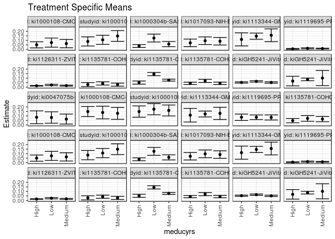

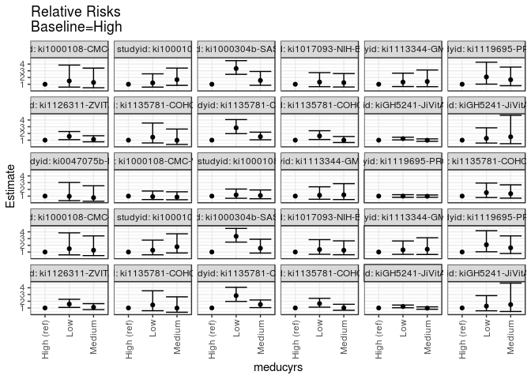

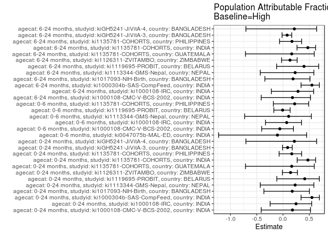

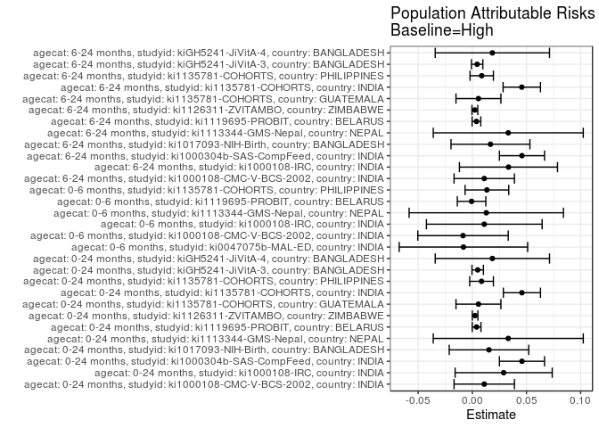

## Results Table

### Parameter: TSM

| agecat | studyid | country | intervention_level | baseline_level | estimate | ci_lower | ci_upper |
| --- | --- | --- | --- | --- | --- | --- | --- |
| 0-24 months | ki1000108-CMC-V-BCS-2002 | INDIA | High | NA | 0.0506329 | 0.0164006 | 0.0848652 |
| 0-24 months | ki1000108-CMC-V-BCS-2002 | INDIA | Low | NA | 0.0754717 | 0.0251181 | 0.1258253 |
| 0-24 months | ki1000108-CMC-V-BCS-2002 | INDIA | Medium | NA | 0.0642202 | 0.0181372 | 0.1103031 |
| 0-24 months | ki1000108-IRC | INDIA | High | NA | 0.0881305 | 0.0373923 | 0.1388688 |
| 0-24 months | ki1000108-IRC | INDIA | Low | NA | 0.1064481 | 0.0558676 | 0.1570286 |
| 0-24 months | ki1000108-IRC | INDIA | Medium | NA | 0.1483846 | 0.0882659 | 0.2085034 |
| 0-24 months | ki1000304b-SAS-CompFeed | INDIA | High | NA | 0.0375958 | 0.0215488 | 0.0536428 |
| 0-24 months | ki1000304b-SAS-CompFeed | INDIA | Low | NA | 0.1256370 | 0.0819409 | 0.1693331 |
| 0-24 months | ki1000304b-SAS-CompFeed | INDIA | Medium | NA | 0.0588288 | 0.0304520 | 0.0872055 |
| 0-24 months | ki1017093-NIH-Birth | BANGLADESH | High | NA | 0.0726079 | 0.0307618 | 0.1144541 |
| 0-24 months | ki1017093-NIH-Birth | BANGLADESH | Low | NA | 0.0959274 | 0.0536425 | 0.1382123 |
| 0-24 months | ki1017093-NIH-Birth | BANGLADESH | Medium | NA | 0.0900806 | 0.0486149 | 0.1315464 |
| 0-24 months | ki1113344-GMS-Nepal | NEPAL | High | NA | 0.1111111 | 0.0384582 | 0.1837641 |
| 0-24 months | ki1113344-GMS-Nepal | NEPAL | Low | NA | 0.1469880 | 0.1128913 | 0.1810846 |
| 0-24 months | ki1113344-GMS-Nepal | NEPAL | Medium | NA | 0.1568627 | 0.0862268 | 0.2274987 |
| 0-24 months | ki1119695-PROBIT | BELARUS | High | NA | 0.0056391 | 0.0012138 | 0.0100643 |
| 0-24 months | ki1119695-PROBIT | BELARUS | Low | NA | 0.0117737 | 0.0059834 | 0.0175641 |
| 0-24 months | ki1119695-PROBIT | BELARUS | Medium | NA | 0.0094214 | 0.0049576 | 0.0138852 |
| 0-24 months | ki1126311-ZVITAMBO | ZIMBABWE | High | NA | 0.0153638 | 0.0119212 | 0.0188063 |
| 0-24 months | ki1126311-ZVITAMBO | ZIMBABWE | Low | NA | 0.0241318 | 0.0168529 | 0.0314107 |
| 0-24 months | ki1126311-ZVITAMBO | ZIMBABWE | Medium | NA | 0.0172372 | 0.0116933 | 0.0227811 |
| 0-24 months | ki1135781-COHORTS | GUATEMALA | High | NA | 0.0287081 | 0.0060586 | 0.0513577 |
| 0-24 months | ki1135781-COHORTS | GUATEMALA | Low | NA | 0.0414938 | 0.0236814 | 0.0593061 |
| 0-24 months | ki1135781-COHORTS | GUATEMALA | Medium | NA | 0.0280899 | 0.0109180 | 0.0452618 |
| 0-24 months | ki1135781-COHORTS | INDIA | High | NA | 0.0511249 | 0.0338120 | 0.0684378 |
| 0-24 months | ki1135781-COHORTS | INDIA | Low | NA | 0.1448565 | 0.1266631 | 0.1630498 |
| 0-24 months | ki1135781-COHORTS | INDIA | Medium | NA | 0.0779349 | 0.0672483 | 0.0886214 |
| 0-24 months | ki1135781-COHORTS | PHILIPPINES | High | NA | 0.0427082 | 0.0298923 | 0.0555241 |
| 0-24 months | ki1135781-COHORTS | PHILIPPINES | Low | NA | 0.0694956 | 0.0521613 | 0.0868299 |
| 0-24 months | ki1135781-COHORTS | PHILIPPINES | Medium | NA | 0.0428831 | 0.0297447 | 0.0560215 |

[output cut: 60 more lines]

### Parameter: E(Y)

| agecat | studyid | country | intervention_level | baseline_level | estimate | ci_lower | ci_upper |
| --- | --- | --- | --- | --- | --- | --- | --- |
| 0-24 months | ki1000108-CMC-V-BCS-2002 | INDIA | NA | NA | 0.0616622 | 0.0372186 | 0.0861058 |
| 0-24 months | ki1000108-IRC | INDIA | NA | NA | 0.1170732 | 0.0859146 | 0.1482317 |
| 0-24 months | ki1000304b-SAS-CompFeed | INDIA | NA | NA | 0.0834553 | 0.0601989 | 0.1067118 |
| 0-24 months | ki1017093-NIH-Birth | BANGLADESH | NA | NA | 0.0880150 | 0.0639627 | 0.1120673 |
| 0-24 months | ki1113344-GMS-Nepal | NEPAL | NA | NA | 0.1443124 | 0.1159091 | 0.1727157 |
| 0-24 months | ki1119695-PROBIT | BELARUS | NA | NA | 0.0095893 | 0.0052864 | 0.0138922 |
| 0-24 months | ki1126311-ZVITAMBO | ZIMBABWE | NA | NA | 0.0179204 | 0.0152268 | 0.0206140 |
| 0-24 months | ki1135781-COHORTS | GUATEMALA | NA | NA | 0.0343840 | 0.0233416 | 0.0454263 |
| 0-24 months | ki1135781-COHORTS | INDIA | NA | NA | 0.0969241 | 0.0882972 | 0.1055510 |
| 0-24 months | ki1135781-COHORTS | PHILIPPINES | NA | NA | 0.0512273 | 0.0430760 | 0.0593786 |
| 0-24 months | kiGH5241-JiVitA-3 | BANGLADESH | NA | NA | 0.0572614 | 0.0531676 | 0.0613553 |
| 0-24 months | kiGH5241-JiVitA-4 | BANGLADESH | NA | NA | 0.0860839 | 0.0717318 | 0.1004359 |
| 0-6 months | ki0047075b-MAL-ED | INDIA | NA | NA | 0.0765550 | 0.0404216 | 0.1126884 |
| 0-6 months | ki1000108-CMC-V-BCS-2002 | INDIA | NA | NA | 0.1396648 | 0.1037072 | 0.1756225 |
| 0-6 months | ki1000108-IRC | INDIA | NA | NA | 0.1592040 | 0.1233945 | 0.1950135 |
| 0-6 months | ki1113344-GMS-Nepal | NEPAL | NA | NA | 0.1205937 | 0.0930759 | 0.1481115 |
| 0-6 months | ki1119695-PROBIT | BELARUS | NA | NA | 0.0846069 | 0.0570929 | 0.1121208 |
| 0-6 months | ki1135781-COHORTS | PHILIPPINES | NA | NA | 0.0609613 | 0.0448957 | 0.0770269 |
| 6-24 months | ki1000108-CMC-V-BCS-2002 | INDIA | NA | NA | 0.0616622 | 0.0372186 | 0.0861058 |
| 6-24 months | ki1000108-IRC | INDIA | NA | NA | 0.1170732 | 0.0859146 | 0.1482317 |
| 6-24 months | ki1000304b-SAS-CompFeed | INDIA | NA | NA | 0.0834553 | 0.0601989 | 0.1067118 |
| 6-24 months | ki1017093-NIH-Birth | BANGLADESH | NA | NA | 0.0880150 | 0.0639627 | 0.1120673 |
| 6-24 months | ki1113344-GMS-Nepal | NEPAL | NA | NA | 0.1443124 | 0.1159091 | 0.1727157 |
| 6-24 months | ki1119695-PROBIT | BELARUS | NA | NA | 0.0095893 | 0.0052864 | 0.0138922 |
| 6-24 months | ki1126311-ZVITAMBO | ZIMBABWE | NA | NA | 0.0179204 | 0.0152268 | 0.0206140 |
| 6-24 months | ki1135781-COHORTS | GUATEMALA | NA | NA | 0.0343840 | 0.0233416 | 0.0454263 |
| 6-24 months | ki1135781-COHORTS | INDIA | NA | NA | 0.0969241 | 0.0882972 | 0.1055510 |
| 6-24 months | ki1135781-COHORTS | PHILIPPINES | NA | NA | 0.0512273 | 0.0430760 | 0.0593786 |
| 6-24 months | kiGH5241-JiVitA-3 | BANGLADESH | NA | NA | 0.0572614 | 0.0531676 | 0.0613553 |
| 6-24 months | kiGH5241-JiVitA-4 | BANGLADESH | NA | NA | 0.0860839 | 0.0717318 | 0.1004359 |

### Parameter: RR

| agecat | studyid | country | intervention_level | baseline_level | estimate | ci_lower | ci_upper |
| --- | --- | --- | --- | --- | --- | --- | --- |
| 0-24 months | ki1000108-CMC-V-BCS-2002 | INDIA | High | High | 1.0000000 | 1.0000000 | 1.000000 |
| 0-24 months | ki1000108-CMC-V-BCS-2002 | INDIA | Low | High | 1.4905660 | 0.5765449 | 3.853624 |
| 0-24 months | ki1000108-CMC-V-BCS-2002 | INDIA | Medium | High | 1.2683486 | 0.4732218 | 3.399481 |
| 0-24 months | ki1000108-IRC | INDIA | High | High | 1.0000000 | 1.0000000 | 1.000000 |
| 0-24 months | ki1000108-IRC | INDIA | Low | High | 1.2078458 | 0.5723475 | 2.548961 |
| 0-24 months | ki1000108-IRC | INDIA | Medium | High | 1.6836913 | 0.8324092 | 3.405556 |
| 0-24 months | ki1000304b-SAS-CompFeed | INDIA | High | High | 1.0000000 | 1.0000000 | 1.000000 |
| 0-24 months | ki1000304b-SAS-CompFeed | INDIA | Low | High | 3.3417837 | 2.4756821 | 4.510885 |
| 0-24 months | ki1000304b-SAS-CompFeed | INDIA | Medium | High | 1.5647706 | 0.8438352 | 2.901641 |
| 0-24 months | ki1017093-NIH-Birth | BANGLADESH | High | High | 1.0000000 | 1.0000000 | 1.000000 |
| 0-24 months | ki1017093-NIH-Birth | BANGLADESH | Low | High | 1.3211698 | 0.6395110 | 2.729413 |
| 0-24 months | ki1017093-NIH-Birth | BANGLADESH | Medium | High | 1.2406443 | 0.5933861 | 2.593924 |
| 0-24 months | ki1113344-GMS-Nepal | NEPAL | High | High | 1.0000000 | 1.0000000 | 1.000000 |
| 0-24 months | ki1113344-GMS-Nepal | NEPAL | Low | High | 1.3228916 | 0.6610114 | 2.647522 |
| 0-24 months | ki1113344-GMS-Nepal | NEPAL | Medium | High | 1.4117647 | 0.6382074 | 3.122934 |
| 0-24 months | ki1119695-PROBIT | BELARUS | High | High | 1.0000000 | 1.0000000 | 1.000000 |
| 0-24 months | ki1119695-PROBIT | BELARUS | Low | High | 2.0878919 | 1.0187721 | 4.278968 |
| 0-24 months | ki1119695-PROBIT | BELARUS | Medium | High | 1.6707370 | 0.7853365 | 3.554352 |
| 0-24 months | ki1126311-ZVITAMBO | ZIMBABWE | High | High | 1.0000000 | 1.0000000 | 1.000000 |
| 0-24 months | ki1126311-ZVITAMBO | ZIMBABWE | Low | High | 1.5706956 | 1.0787788 | 2.286924 |
| 0-24 months | ki1126311-ZVITAMBO | ZIMBABWE | Medium | High | 1.1219359 | 0.7580815 | 1.660429 |
| 0-24 months | ki1135781-COHORTS | GUATEMALA | High | High | 1.0000000 | 1.0000000 | 1.000000 |
| 0-24 months | ki1135781-COHORTS | GUATEMALA | Low | High | 1.4453665 | 0.5887096 | 3.548582 |
| 0-24 months | ki1135781-COHORTS | GUATEMALA | Medium | High | 0.9784644 | 0.3606476 | 2.654648 |
| 0-24 months | ki1135781-COHORTS | INDIA | High | High | 1.0000000 | 1.0000000 | 1.000000 |
| 0-24 months | ki1135781-COHORTS | INDIA | Low | High | 2.8333860 | 1.9751800 | 4.064478 |
| 0-24 months | ki1135781-COHORTS | INDIA | Medium | High | 1.5244026 | 1.0583221 | 2.195743 |
| 0-24 months | ki1135781-COHORTS | PHILIPPINES | High | High | 1.0000000 | 1.0000000 | 1.000000 |
| 0-24 months | ki1135781-COHORTS | PHILIPPINES | Low | High | 1.6272202 | 1.1016717 | 2.403480 |
| 0-24 months | ki1135781-COHORTS | PHILIPPINES | Medium | High | 1.0040962 | 0.6541115 | 1.541342 |

[output cut: 60 more lines]

### Parameter: PAR

| agecat | studyid | country | intervention_level | baseline_level | estimate | ci_lower | ci_upper |
| --- | --- | --- | --- | --- | --- | --- | --- |
| 0-24 months | ki1000108-CMC-V-BCS-2002 | INDIA | High | NA | 0.0110293 | -0.0168377 | 0.0388962 |
| 0-24 months | ki1000108-IRC | INDIA | High | NA | 0.0289426 | -0.0158665 | 0.0737518 |
| 0-24 months | ki1000304b-SAS-CompFeed | INDIA | High | NA | 0.0458596 | 0.0250560 | 0.0666631 |
| 0-24 months | ki1017093-NIH-Birth | BANGLADESH | High | NA | 0.0154070 | -0.0213098 | 0.0521239 |
| 0-24 months | ki1113344-GMS-Nepal | NEPAL | High | NA | 0.0332013 | -0.0360426 | 0.1024451 |
| 0-24 months | ki1119695-PROBIT | BELARUS | High | NA | 0.0039502 | -0.0000814 | 0.0079818 |
| 0-24 months | ki1126311-ZVITAMBO | ZIMBABWE | High | NA | 0.0025566 | -0.0000286 | 0.0051418 |
| 0-24 months | ki1135781-COHORTS | GUATEMALA | High | NA | 0.0056758 | -0.0150637 | 0.0264153 |
| 0-24 months | ki1135781-COHORTS | INDIA | High | NA | 0.0457992 | 0.0286542 | 0.0629442 |
| 0-24 months | ki1135781-COHORTS | PHILIPPINES | High | NA | 0.0085191 | -0.0024354 | 0.0194737 |
| 0-24 months | kiGH5241-JiVitA-3 | BANGLADESH | High | NA | 0.0049858 | -0.0002906 | 0.0102622 |
| 0-24 months | kiGH5241-JiVitA-4 | BANGLADESH | High | NA | 0.0185163 | -0.0342483 | 0.0712809 |
| 0-6 months | ki0047075b-MAL-ED | INDIA | High | NA | -0.0081907 | -0.0674787 | 0.0510972 |
| 0-6 months | ki1000108-CMC-V-BCS-2002 | INDIA | High | NA | -0.0085750 | -0.0503238 | 0.0331739 |
| 0-6 months | ki1000108-IRC | INDIA | High | NA | 0.0110461 | -0.0423585 | 0.0644506 |
| 0-6 months | ki1113344-GMS-Nepal | NEPAL | High | NA | 0.0129014 | -0.0583351 | 0.0841379 |
| 0-6 months | ki1119695-PROBIT | BELARUS | High | NA | -0.0006833 | -0.0138400 | 0.0124734 |
| 0-6 months | ki1135781-COHORTS | PHILIPPINES | High | NA | 0.0134690 | -0.0066777 | 0.0336157 |
| 6-24 months | ki1000108-CMC-V-BCS-2002 | INDIA | High | NA | 0.0110293 | -0.0168377 | 0.0388962 |
| 6-24 months | ki1000108-IRC | INDIA | High | NA | 0.0333920 | -0.0118727 | 0.0786568 |
| 6-24 months | ki1000304b-SAS-CompFeed | INDIA | High | NA | 0.0458596 | 0.0250560 | 0.0666631 |
| 6-24 months | ki1017093-NIH-Birth | BANGLADESH | High | NA | 0.0167662 | -0.0196578 | 0.0531901 |
| 6-24 months | ki1113344-GMS-Nepal | NEPAL | High | NA | 0.0332013 | -0.0360426 | 0.1024451 |
| 6-24 months | ki1119695-PROBIT | BELARUS | High | NA | 0.0038229 | -0.0001892 | 0.0078350 |
| 6-24 months | ki1126311-ZVITAMBO | ZIMBABWE | High | NA | 0.0023676 | -0.0003102 | 0.0050454 |
| 6-24 months | ki1135781-COHORTS | GUATEMALA | High | NA | 0.0056758 | -0.0150637 | 0.0264153 |
| 6-24 months | ki1135781-COHORTS | INDIA | High | NA | 0.0456692 | 0.0284116 | 0.0629268 |
| 6-24 months | ki1135781-COHORTS | PHILIPPINES | High | NA | 0.0086954 | -0.0020840 | 0.0194749 |
| 6-24 months | kiGH5241-JiVitA-3 | BANGLADESH | High | NA | 0.0044642 | -0.0007959 | 0.0097243 |
| 6-24 months | kiGH5241-JiVitA-4 | BANGLADESH | High | NA | 0.0185163 | -0.0342483 | 0.0712809 |

### Parameter: PAF

| agecat | studyid | country | intervention_level | baseline_level | estimate | ci_lower | ci_upper |
| --- | --- | --- | --- | --- | --- | --- | --- |
| 0-24 months | ki1000108-CMC-V-BCS-2002 | INDIA | High | NA | 0.1788663 | -0.4151376 | 0.5235371 |
| 0-24 months | ki1000108-IRC | INDIA | High | NA | 0.2472183 | -0.2451928 | 0.5449056 |
| 0-24 months | ki1000304b-SAS-CompFeed | INDIA | High | NA | 0.5495101 | 0.3421911 | 0.6914892 |
| 0-24 months | ki1017093-NIH-Birth | BANGLADESH | High | NA | 0.1750502 | -0.3645289 | 0.5012621 |
| 0-24 months | ki1113344-GMS-Nepal | NEPAL | High | NA | 0.2300654 | -0.4328814 | 0.5862886 |
| 0-24 months | ki1119695-PROBIT | BELARUS | High | NA | 0.4119417 | -0.1183909 | 0.6907946 |
| 0-24 months | ki1126311-ZVITAMBO | ZIMBABWE | High | NA | 0.1426650 | -0.0125179 | 0.2740639 |
| 0-24 months | ki1135781-COHORTS | GUATEMALA | High | NA | 0.1650718 | -0.7149568 | 0.5935145 |
| 0-24 months | ki1135781-COHORTS | INDIA | High | NA | 0.4725268 | 0.2690778 | 0.6193466 |
| 0-24 months | ki1135781-COHORTS | PHILIPPINES | High | NA | 0.1663004 | -0.0753286 | 0.3536347 |
| 0-24 months | kiGH5241-JiVitA-3 | BANGLADESH | High | NA | 0.0870707 | -0.0099902 | 0.1748039 |
| 0-24 months | kiGH5241-JiVitA-4 | BANGLADESH | High | NA | 0.2150959 | -0.7067246 | 0.6390311 |
| 0-6 months | ki0047075b-MAL-ED | INDIA | High | NA | -0.1069915 | -1.2256042 | 0.4493944 |
| 0-6 months | ki1000108-CMC-V-BCS-2002 | INDIA | High | NA | -0.0613967 | -0.4062960 | 0.1989148 |
| 0-6 months | ki1000108-IRC | INDIA | High | NA | 0.0693831 | -0.3340521 | 0.3508141 |
| 0-6 months | ki1113344-GMS-Nepal | NEPAL | High | NA | 0.1069822 | -0.7296280 | 0.5389293 |
| 0-6 months | ki1119695-PROBIT | BELARUS | High | NA | -0.0080760 | -0.1750609 | 0.1351791 |
| 0-6 months | ki1135781-COHORTS | PHILIPPINES | High | NA | 0.2209433 | -0.1839491 | 0.4873687 |
| 6-24 months | ki1000108-CMC-V-BCS-2002 | INDIA | High | NA | 0.1788663 | -0.4151376 | 0.5235371 |
| 6-24 months | ki1000108-IRC | INDIA | High | NA | 0.2852237 | -0.2219681 | 0.5818997 |
| 6-24 months | ki1000304b-SAS-CompFeed | INDIA | High | NA | 0.5495101 | 0.3421911 | 0.6914892 |
| 6-24 months | ki1017093-NIH-Birth | BANGLADESH | High | NA | 0.1904921 | -0.3459007 | 0.5131119 |
| 6-24 months | ki1113344-GMS-Nepal | NEPAL | High | NA | 0.2300654 | -0.4328814 | 0.5862886 |
| 6-24 months | ki1119695-PROBIT | BELARUS | High | NA | 0.3986602 | -0.1221558 | 0.6777546 |
| 6-24 months | ki1126311-ZVITAMBO | ZIMBABWE | High | NA | 0.1321158 | -0.0292974 | 0.2682164 |
| 6-24 months | ki1135781-COHORTS | GUATEMALA | High | NA | 0.1650718 | -0.7149568 | 0.5935145 |
| 6-24 months | ki1135781-COHORTS | INDIA | High | NA | 0.4711854 | 0.2659359 | 0.6190457 |
| 6-24 months | ki1135781-COHORTS | PHILIPPINES | High | NA | 0.1697423 | -0.0672744 | 0.3541231 |
| 6-24 months | kiGH5241-JiVitA-3 | BANGLADESH | High | NA | 0.0779613 | -0.0187776 | 0.1655143 |
| 6-24 months | kiGH5241-JiVitA-4 | BANGLADESH | High | NA | 0.2150959 | -0.7067246 | 0.6390311 |